# Project 3 Notebook Report

### Introduction

The RUNX1 transcription factor is a part of a family of proteins that are known for being master regulators. Their well defined behavior has inherently tied them into playing important roles in cancer development. RUNX1 specifically has been strongly associated with breast cancer, where it can act as both a tumor suppressor and an oncogene. RUNX1 acts through the alteration of chromatin structure alongside other chromatin modifiers and remodeling enzymes. The study in question specifically aimed to investigate the relationship between RUNX1 mediated transcription and the resulting genome organization. As changes in nuclear architecture are often observed in cases of breast cancer alongside the overexpression of RUNX1, investigating this relationship will help make a more complete picture into breast cancer development. To approach this problem, the authors used a variety of different methods with two conditions, cells with a suppression RUNX1 and cells with no suppression of RUNX1. First, the authors employed a Hi-C approach in order to examine both inter- and intra-chromosomal interactions between both conditions. Next, they utilized RNA-seq analysis in order to compare the gene expression profile of these two conditions. In addition to this, the authors performed a ChIP-seq analysis in order to investigate RUNX1-mediated regulation of chromatin organization through its binding patterns on the chromatin.

### Methods

To begin this analysis, single end reads were obtained from a ChIPseq experiment that was done in a well established breast cancer line, MCF-7. The quality of these reads were first analyzed using FastQC v0.12.1 with default parameters [1]. At the same time, the GRCh38 human reference genome was indexed using default Bowtie2 v2.5.4 parameters [2]. The adapters and low quality bases were trimmed from the reads using the single end command with default parameters from Trimmomatic v0.40 [3]. Upon completion, the reads were aligned to the previously indexed human reference genome using Bowtie2 v2.5.4 with default parameters [4]. Further quality control was then completed using default MultiQC v1.25 [5] and the default flagstat utility from Samtools v1.22.1 [6]. These alignment files were then sorted in genomic order based on their alignment to the reference genome and indexed using Samtools v1.22.1 with default parameters for further analysis [7].

Bigwig files were generated from the previously sorted BAM files using default deeptools v3.5.5 and signal coverage plots were calculated using deeptools’s computeMatrix utility [8]. These plots included 2000 bp cushions on either side of the transcription start site and end site.A spearman correlation analysis was also performed with deeptools v3.5.5 utilities plotcorrelation and multibwsummary with default parameters to determine the similarity between samples [9].

Peak calling was executed using the HOMER suite v4.11 using the “-style factor” option [10]. To create one set of reproducible peaks, the peaks were intersected using a simple intersection method using the intersect utility of bedtools v2.31.1 [11]. Any peaks that overlapped in undesirable regions as denoted by the hg38-blacklist v2 as poised by the Boyle lab (https://github.com/Boyle-Lab/Blacklist/tree/master/lists) were removed through the default use of bedtools v2.31.1 [12]. Peak annotation and motif finding was done on the set of filtered peaks using the HOMER suite v4.11 with default options [13]. These peaks were lastly analyzed using the online web tool ENRICR in order to identify any associated biological processes [14].

### Justification for Methods Choices

1. When plotting the distances of the correlation coefficients of each sample to determine the similarity of our samples, I chose to utilize a spearman correlation. This is because I thought that the data might have been monotonic and not linear due to the technical variability that is often seen in ChIP-seq experiments through things like sequencing depth and immunoprecipitation efficiency between samples.
2. When producing a set of reproducible peaks with bedtools intersect, I employed the simple intersection method. I chose this method as it only retains peaks that overlap in both replicates and boasts a higher confidence despite being the most stringent of the strategies.

### Quality Control Evaluation

Looking through the MultiQC report shows that the data gathered from the experiment is usable for downstream analysis. First, the general statistics report shows that 3 of the 4 samples have a mapped read depth of around 30 million and 1 sample has a mapped read depth of around 10 million. Consulting the original Fastq files reveals that this dramatic decrease in read depth is present before anything was done with the samples. Further, the Samtools flagstat metrics report that each sample had an alignment rate of the reads to the reference genome at higher than 90%, which is a good sign when compared to the standard alignment of 70%. Looking at the results of Trimmomatic shows that the vast majority of reads in each sample survived, as less than 400,000 reads were dropped for each sample, which is also a good sign.

### Signal Coverage Plot

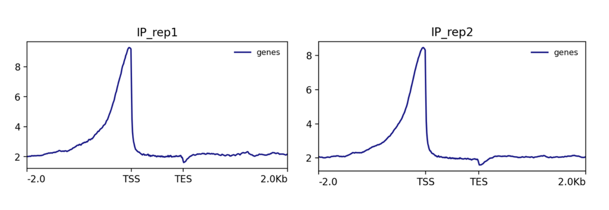

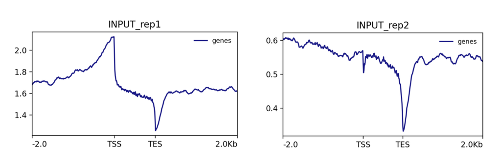

A signal coverage plot conveys information regarding the number of sequencing reads that align to specific positions along a reference genome or targeted region to visualize depth and distribution of sequencing data. The plots associated with the IP samples in this ChIP experiment show a sharp, tall peak near the transcription start site (TSS) mark and no peak near the transcription end site (TES). This suggests that the RUNX1 protein binds promoter regions and is more associated with transcription initiation as opposed to transcription elongation or termination. The plots associated with the INPUT samples both show little to no consistent TSS enrichment as in the IP samples. Due to this, the INPUT samples help to validate the results obtained from the IP samples.

### Motif Finding

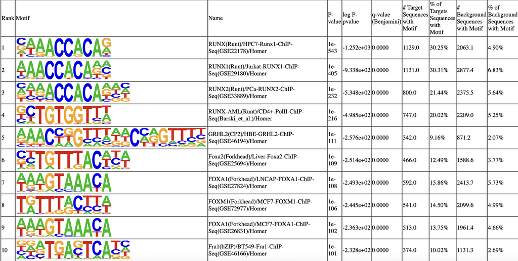

Above are the top 10 motifs that were compiled in the knownResults output from HOMER. The top 4 motifs belong to the runt family domains, while another four belong to the forkhead family domains. The remaining two domains belong to the bZIP and CP2 family domains. These results make sense in the context of this experiment due to the fact that these are all DNA binding domains. These results help confirm that the ChIP-seq peaks produced were enriched for genuine transcription factor binding sites and are consistent with the observations made from the signal coverage plots above.

### Overlap ChIPseq results with the original RNAseq data

##### Figure 2F (Code for this figure can be found in the python workbook):

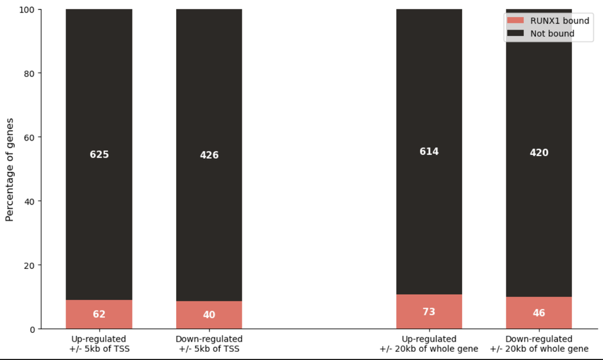

##### Figure 2D - MALAT1 Figure:

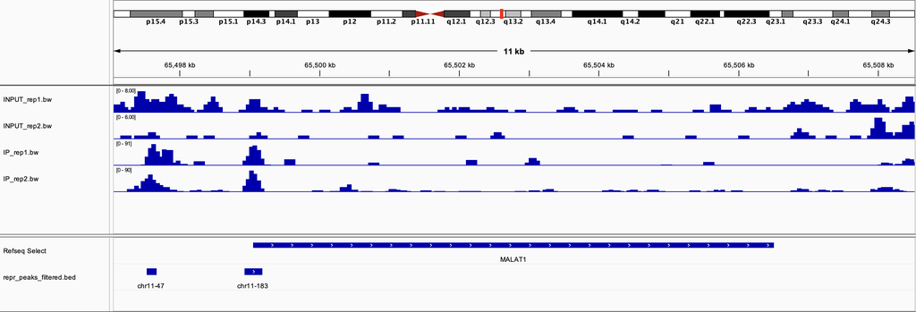

##### Figure 2E - NEAT1 Figure:

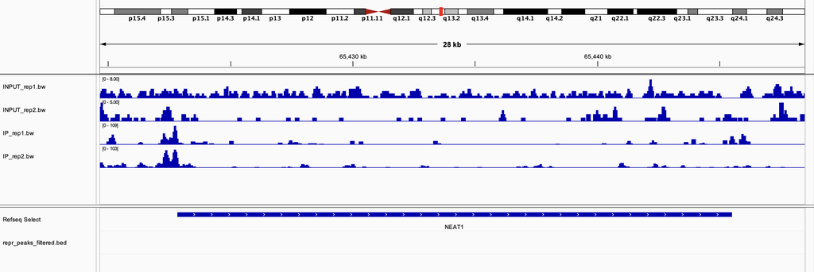

Comparing this report's results with the data presented in figure 2F of the paper reveals that a different number of overlapping genes were identified. The authors report that within +/- 5kb of the transcription start site, 59 genes were upregulated and bound, and 48 were down regulated and bound. However this analysis shows that within the same region, 62 genes were upregulated and bound, and 40 genes were downregulated and bound. This difference is also seen when expanding the region to encapsulate +/- 20kb of the whole gene. In the paper, this region has 161 genes that are upregulated and bound and 120 genes that are down regulated and bound. In this analysis, it was found that there were 73 upregulated and bound genes and 46 downregulated and bound genes. There could be multiple reasons for this difference. First, the authors of this paper use a different reference genome (hg19) than this analysis does (hg38). The change in the reference genome could have also changed gene boundaries, which would impact on the annotation of genes. Additionally, the authors do not explain what their method of finding peaks was, which could result in a very different peak list than what was found in this analysis. Combining this RNAseq data with the ChIP seq allows for the identification of which genes are both differentially expressed as well as bound to RUNX1. From this information you can further conclude information regarding RUNX1 direct targets and its downstream effects, giving a clearer picture into its gene expression.

Using the analysis from this report, 2 statistically significant peaks were able to be identified from the reproducible and filtered peak list in the MALAT1 gene. These peaks are labeled from the reproducible bed filtered file as chr11-47 and chr11-183. The authors of the paper were also able to find 2 statistically significant peaks. The genomic tracks associated with the input samples from the paper show a flat line while the track associated with the IP samples shows two spiking peaks and many small peaks. This is not reflected with how the genomic tracks look from this analysis as the genomic tracks associated with the inputs display more peaks than the genomic tracks associated with the IP samples.

The analysis from this report also shows that there are 0 statistically significant peaks that were able to be identified in the NEAT1 gene. The authors of the paper were able to find 2 statistically significant peaks. The genomic tracks associated with the input samples from the paper show a flat line while the track associated with the IP samples shows two spiking peaks and many small peaks along with it as well. The data from my analysis shows that the genomic tracks associated with the IP samples are flatter than the tracks that are associated with the input samples.These discrepancies can be due to many things, such as those already listed above. The fact that these two analyses use different reference genomes as well as having different methods of determining peaks leaves room for differences presented within the data.

## Comparing key findings to the original paper

##### Figure S2A: Table (Code for this figure can be found in the python workbook)

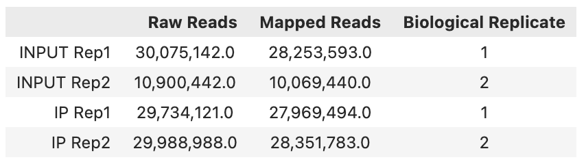

##### Figure S2B: Heatmap

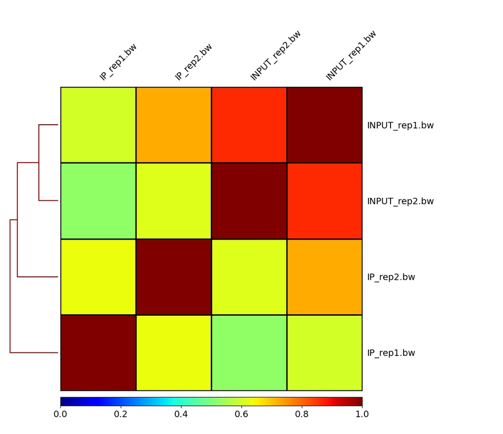

##### Figure S2C: Venn Diagram (Code for this figure can be found in the python workbook)

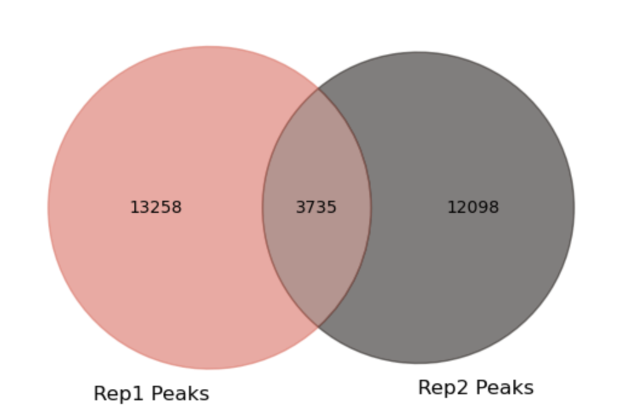

The venn diagrams synthesized from the analysis done in the paper and the analysis done throughout this report shows that the number of peaks found in both replicate 1 and replicate 2 are reasonably similar and that the number of peaks from each replicate noticeably differ. First, the paper reports that there were 3,466 peaks that were found in both replicates while my analysis reported that there were 3,735 peaks. However, the authors report that they found 3,983 peaks in replicate 1 and 10,465 peaks in replicate 2 while the analysis done in this report shows 13,258 peaks found in replicate 1, 12,098 peaks in replicate 2. There could be multiple reasons for these discrepancies in the number of called peaks. First, the authors used the hg19 reference genome as opposed to the hg38, which is what the analysis in this report uses. These reference genomes differ by thousands of basepairs, which can easily give different results. Further, this analysis was able to map many more reads than the original paper. These additional reads could have had many of the peaks that were identified in this report that were not identified in the paper.

### Analyze the annotated peaks

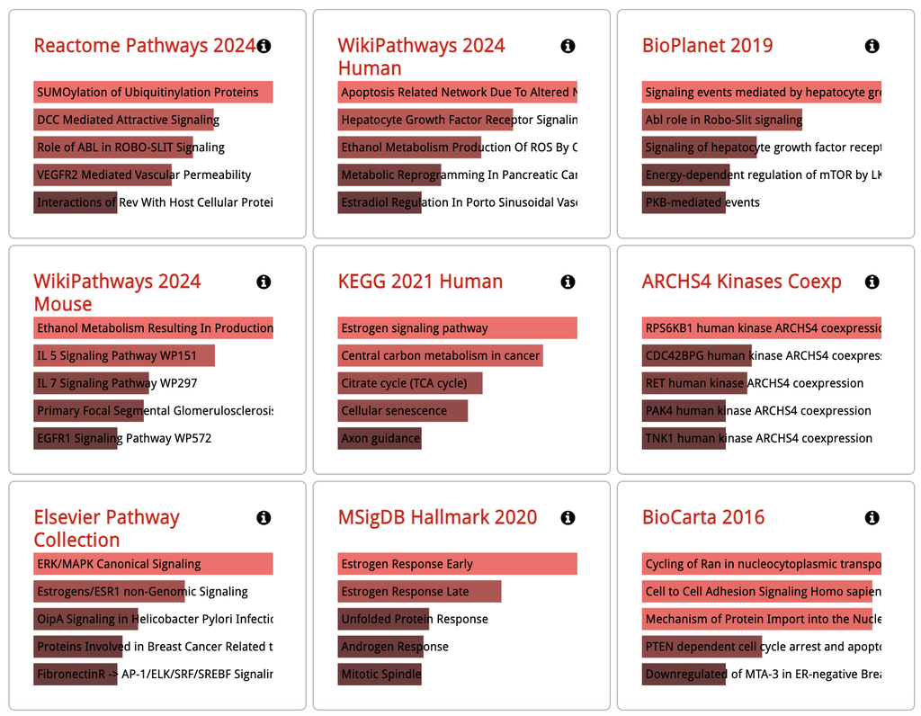

To perform this enrichment, gene names were collected from the file that contains the reproduceable, HOMER-annotated peaks that were then ran through the online gene enrichment tool, ENRICHR. The results that were obtained from this search made logical sense when compared to the subject of the paper as many of the hits were consistent with RUNX1’s known biology in breast cancer. The most common hit was related to the estrogen signaling pathway, which is known to stimulate growth of ER-positive breast cancer tumors through both genomic and non-genomic pathways, aligning with RUNX1’s role as an estrogen receptor co-regulator in MCF-7 cells. This hit was found in the KEGG 2021 Human Pathway, MSigDB Hallmark 2020 Pathway, and the Elsevier Pathway Collection. Other common hits included items related to cell adhesion and migration as well as PI3K/AKT relevant signaling pathways, such as PTEN and PKB, which play a role in tumor suppressor functions. These results are interesting because they help to form a preliminary hypothesis that RUNX1 may coordinate both proliferative and growth-suppressive processes in MCF-7 cells, aligning to its context-dependent role in breast cancer.

### References

[1] Andrews, S. FastQC: A Quality Control Tool for High Throughput Sequence Data [Online]. Available online at: http://www.bioinformatics.babraham.ac.uk/projects/fastqc/ (2010).

[2] Langmead, B., Salzberg, S. Fast gapped-read alignment with Bowtie 2. Nature Methods. 9:357-359. (2012).

[3] Bolger, A. M., Lohse, M., & Usadel, B. Trimmomatic: A flexible trimmer for Illumina Sequence Data. Bioinformatics, btu170. (2014).

[4] Langmead, B., Salzberg, S. Fast gapped-read alignment with Bowtie 2. Nature Methods. 9:357-359. (2012). [5] Ewels, P. et al. MultiQC: summarize analysis results for multiple tools and samples in a single report. Bioinformatics 32, 19 (2016).

[6] Li, H., Handsaker, B., Wysoker, A., Fennell, T., Ruan, J., Homer, N., Marth, G., Abecasis, G., Durbin, R. 1000 Genome Project Data Processing Subgroup, The Sequence Alignment/Map format and SAMtools, Bioinformatics, Volume 25, Issue 16, Pages 2078–2079, https://doi.org/10.1093/bioinformatics/btp352 (2009).

[7] Li, H., Handsaker, B., Wysoker, A., Fennell, T., Ruan, J., Homer, N., Marth, G., Abecasis, G., Durbin, R. 1000 Genome Project Data Processing Subgroup, The Sequence Alignment/Map format and SAMtools, Bioinformatics, Volume 25, Issue 16, Pages 2078–2079, https://doi.org/10.1093/bioinformatics/btp352 (2009).

[8] Fidel, R., Ryan, D.P., Grüning, B., Bhardwaj, V., Kilpert, F., Richter, A.S, Heyne, S., Dündar, F., and Manke T. deepTools2: A next Generation Web Server for Deep-Sequencing Data Analysis. Nucleic Acids Research. doi:10.1093/nar/gkw257. (2016).

[9] Fidel, R., Ryan, D.P., Grüning, B., Bhardwaj, V., Kilpert, F., Richter, A.S, Heyne, S., Dündar, F., and Manke T. deepTools2: A next Generation Web Server for Deep-Sequencing Data Analysis. Nucleic Acids Research. doi:10.1093/nar/gkw257. (2016).

[10] Heinz S, Benner C, Spann N, Bertolino E et al. Simple Combinations of Lineage-Determining Transcription Factors Prime cis-Regulatory Elements Required for Macrophage and B Cell Identities. Mol Cell 2010 May 28;38(4):576-589. PMID: 20513432. (2010).

[11] Aaron R. Quinlan, Ira M. Hall, BEDTools: a flexible suite of utilities for comparing genomic features, Bioinformatics, Volume 26, Issue 6, March 2010, Pages 841–842, https://doi.org/10.1093/bioinformatics/btq033

[12] Aaron R. Quinlan, Ira M. Hall, BEDTools: a flexible suite of utilities for comparing genomic features, Bioinformatics, Volume 26, Issue 6, March 2010, Pages 841–842, https://doi.org/10.1093/bioinformatics/btq033

[13] Heinz S, Benner C, Spann N, Bertolino E et al. Simple Combinations of Lineage-Determining Transcription Factors Prime cis-Regulatory Elements Required for Macrophage and B Cell Identities. Mol Cell 2010 May 28;38(4):576-589. PMID: 20513432. (2010).

[14] Chen, E.Y.,et al. Enrichr: interactive and collaborative HTML5 gene list enrichment analysis tool. BMC Bioinformatics, 14, 128. (2013).